# Visualize and interpret kinetics data

Melanie (1028-02098-001-001)

April 03, 2026

# Introduction

The goal of this document is to visualize the kinetics simulations produced earlier and to summarize outcomes of accessibility and binding to interpret different modes of cooperativity.

# Computational Setup

```r
#Standard packages
library(rtracklayer) ; library(GenomicRanges); library(magrittr) ; library(Biostrings)
library(ggplot2) ; library(reshape2); library(plyranges); library(Rsamtools); library(parallel)
library(dplyr); library(data.table); library(patchwork); library(readr); library(testit)

#KNITR Options
setwd("/n/projects/mw2098/publications/2024_weilert_acc/code/2_analysis/")
figure_filepath<-"figures/19_visualize_kinetics"
options(knitr.figure_dir=figure_filepath, java.parameters = "- Xmx6g")

#Lab sources
source("scripts/r/granges_common.r")
source("scripts/r/metapeak_common.r")
source("scripts/r/knitr_common.r")
source("scripts/r/caching.r")
source("scripts/r/metapeak_functions.r")

#Specific sources
library(BSgenome.Mmusculus.UCSC.mm10)
library(TxDb.Mmusculus.UCSC.mm10.knownGene)
library(ggseqlogo)
library(ggrastr)
library(basicdrm)
source("scripts/r/motif_functions.r")

#Pre-existing variables
bsgenome<-BSgenome.Mmusculus.UCSC.mm10
txdb<-TxDb.Mmusculus.UCSC.mm10.knownGene
kinetics.path<-'tsv/kinetics/kinetics_8state_scenarios.tsv.gz'

conc_levels.df<-readr::read_tsv('tsv/kinetics/conc_by_seq.tsv.gz') %>%
  dplyr::mutate(conc_levels = 1:nrow(.),
                log10_kon = log10(kon))
conc_levels_n<-nrow(conc_levels.df)
```

# Plot S/S

In the event of plausible Sox2/Sox2 motif binding and pioneering, what cooperativity emerges from the accessibility (as represented by p(open) at the two states)?

```r
#Set limits
marginal_limits <- c(0, .85)
joint_limits <- c(0, .85)
```

We want to explain some features. For this, we will classify certain components.

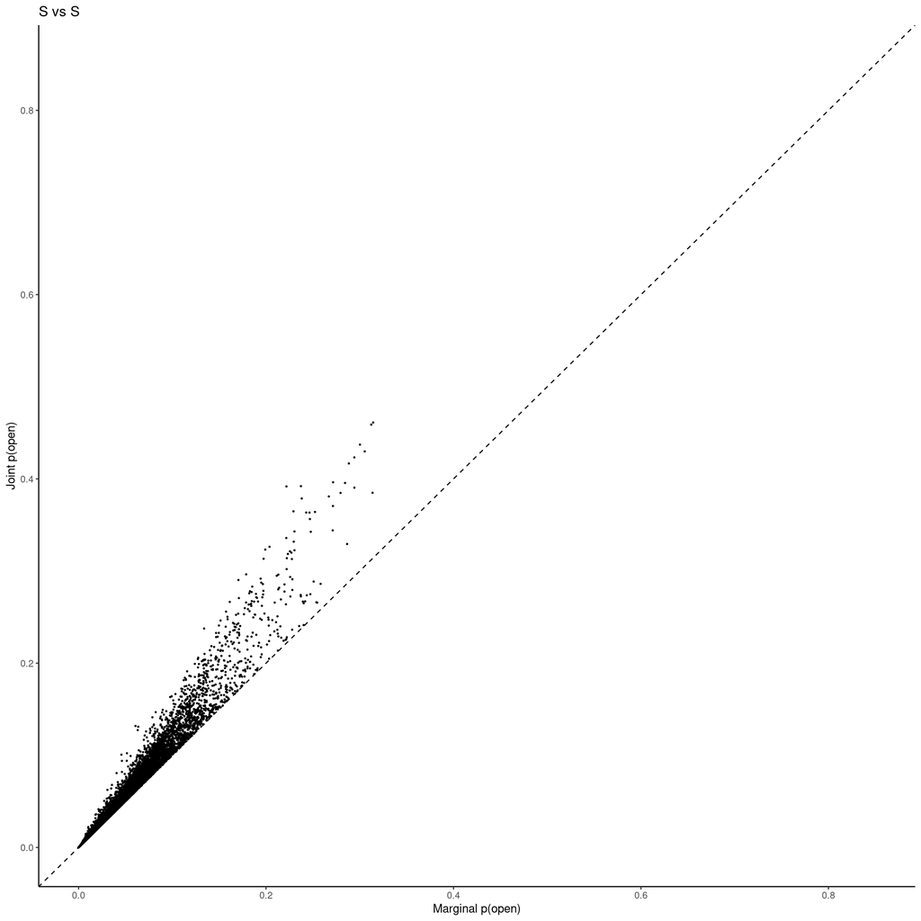

```r
s_vs_s.df<-readr::read_tsv('tsv/kinetics/kinetics_8state_scenarios_SvsS.tsv.gz')

s_vs_s_acc.plot<-ggplot(s_vs_s.df, aes(x = acc_marg, y = acc_joint))+
  geom_abline(slope = 1, intercept = 0, linetype = 'dashed')+
  ggrastr::geom_point_rast(size = .1)+
  # ggrastr::geom_point_rast(aes(color = a1Bvals + a1Avals), size = .1)+
  scale_x_continuous(limits = marginal_limits, name = 'Marginal p(open)')+
  scale_y_continuous(limits = joint_limits, name = 'Joint p(open)')+

  ggtitle('S vs S')+
  theme_classic() + theme(legend.position = 'none')
s_vs_s_acc.plot
```

# Plot S/OS

In the event of plausible Sox2/Oct4-Sox2 motif binding and pioneering, what cooperativity emerges from the accessibility (as represented by p(open) at the two states)?

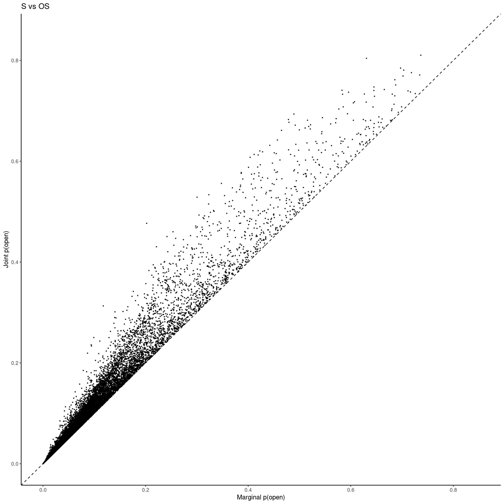

```r
s_vs_os.df<-readr::read_tsv('tsv/kinetics/kinetics_8state_scenarios_SvsOS.tsv.gz') %>%
  dplyr::mutate(a1Avals_bin = cut(a1Avals, breaks = c(0, 3, 7, 10), include.lowest = T))

s_vs_os_acc.plot<-ggplot(s_vs_os.df, aes(x = acc_marg, y = acc_joint))+
  geom_abline(slope = 1, intercept = 0, linetype = 'dashed')+
  ggrastr::geom_point_rast(size = .1)+
  # ggrastr::geom_point_rast(aes(color = a1Avals_bin), size = .1)+
  scale_x_continuous(limits = marginal_limits, name = 'Marginal p(open)')+
  scale_y_continuous(limits = joint_limits, name = 'Joint p(open)')+
  # scale_color_manual(values = viridis(n=3))+
  ggtitle('S vs OS')+
  theme_classic() + theme(legend.position = 'none')
s_vs_os_acc.plot
```

Consolidate and output.

```r
plot<-s_vs_s_acc.plot + s_vs_os_acc.plot + plot_layout(nrow = 1, widths = c(1, 1))
ggsave(paste0(figure_filepath, '/joint_vs_marg_S_vs_OS.png'), height = 4, width = 8)
ggsave(paste0(figure_filepath, '/joint_vs_marg_S_vs_OS.pdf'), height = 4, width = 8)
```

# Plot concentration effects

Here, we will select a series of parameters over changing concentrations such that we can show (1) accessibility is higher when two TFs pioneer than when one does (this is superadditive) and (2) cooperativity (relative) peaks at different concentrations for different affinities.

## S/TFB when S changes and TF B does not

We will select a scenario with a less tight nucleosome and moderate pioneering.

Plot Sox2 effects (A) when concentration of Sox2 (A) is changing and ONLY affinities of Sox2 (A) is changing in the presence of another pioneering TF (B) with unchanging affinities and concentration.

```r
conc.df<-Sys.glob('tsv/kinetics/os_sameclosing=True_*_a1=4.00-6.00_a2f=3.25-5.50_d=0.01-0.01_betam=5.tsv.gz') %>%
  lapply(., function(x){

    #Rows are trials, comma separators are the concentrations
    coop.df<-readr::read_tsv(x) %>% tidyr::separate(col = 'acc_coopvals', sep = ',', into = c(1:conc_levels_n) %>% as.character) %>%
      dplyr::mutate(trial = 1:nrow(.)) %>%
      tidyr::pivot_longer(cols = c(1:conc_levels_n) %>% as.character, names_to = 'conc_levels', values_to = 'acc_coopvals') %>% dplyr::select(acc_coopvals, conc_levels, trial)%>%
      dplyr::mutate(acc_coopvals = as.numeric(acc_coopvals))
    A_only.df<-readr::read_tsv(x) %>% tidyr::separate(col = 'acc_Aonly', sep = ',', into = c(1:conc_levels_n) %>% as.character) %>%
      dplyr::mutate(trial = 1:nrow(.)) %>%
      tidyr::pivot_longer(cols = c(1:conc_levels_n) %>% as.character, names_to = 'conc_levels', values_to = 'acc_Aonly') %>% dplyr::select(acc_Aonly, conc_levels, trial) %>%
      dplyr::mutate(acc_Aonly = as.numeric(acc_Aonly))
    B_only.df<-readr::read_tsv(x) %>% tidyr::separate(col = 'acc_Bonly', sep = ',', into = c(1:conc_levels_n) %>% as.character) %>%
      dplyr::mutate(trial = 1:nrow(.)) %>%
      tidyr::pivot_longer(cols = c(1:conc_levels_n) %>% as.character, names_to = 'conc_levels', values_to = 'acc_Bonly') %>% dplyr::select(acc_Bonly, conc_levels, trial) %>%
      dplyr::mutate(acc_Bonly = as.numeric(acc_Bonly))
    AB.df<-readr::read_tsv(x) %>% tidyr::separate(col = 'acc_AB', sep = ',', into = c(1:conc_levels_n) %>% as.character) %>%
      dplyr::mutate(trial = 1:nrow(.)) %>%
      tidyr::pivot_longer(cols = c(1:conc_levels_n) %>% as.character, names_to = 'conc_levels', values_to = 'acc_AB') %>% dplyr::select(acc_AB, conc_levels, trial) %>%
      dplyr::mutate(acc_AB = as.numeric(acc_AB))


    bindAonly.df<-readr::read_tsv(x) %>% tidyr::separate(col = 'bind_Aonly', sep = ',', into = c(1:conc_levels_n) %>% as.character) %>%
      dplyr::mutate(trial = 1:nrow(.)) %>%
      tidyr::pivot_longer(cols = c(1:conc_levels_n) %>% as.character, names_to = 'conc_levels', values_to = 'bind_Aonly') %>% dplyr::select(bind_Aonly, conc_levels, trial) %>%
      dplyr::mutate(bind_Aonly = as.numeric(bind_Aonly))

    bindBonly.df<-readr::read_tsv(x) %>% tidyr::separate(col = 'bind_Bonly', sep = ',', into = c(1:conc_levels_n) %>% as.character) %>%
      dplyr::mutate(trial = 1:nrow(.)) %>%
      tidyr::pivot_longer(cols = c(1:conc_levels_n) %>% as.character, names_to = 'conc_levels', values_to = 'bind_Bonly') %>% dplyr::select(bind_Bonly, conc_levels, trial) %>%
      dplyr::mutate(bind_Bonly = as.numeric(bind_Bonly))

    bindA_AB.df<-readr::read_tsv(x) %>% tidyr::separate(col = 'bindA_ABonly', sep = ',', into = c(1:conc_levels_n) %>% as.character) %>%
      dplyr::mutate(trial = 1:nrow(.)) %>%
      tidyr::pivot_longer(cols = c(1:conc_levels_n) %>% as.character, names_to = 'conc_levels', values_to = 'bindA_ABonly') %>% dplyr::select(bindA_ABonly, conc_levels, trial) %>%
      dplyr::mutate(bindA_ABonly = as.numeric(bindA_ABonly))

    #Assign parameters in case people are interested
     parameter_order<-c('kon', 'konB', 'koff1nA','koff1nB','gA','gB','betanA', 'betanB', 'betamA', 'betamB','h0','h1', 'kopen0','kclose0', 'a1nA', 'a1nB', 'a1nAB', 'a1mA', 'a1mB', 'a1mAnB', 'a1nAmB', 'a1mAmB', 'a2nA', 'a2nB', 'a2nAB', 'a2mA', 'a2mB', 'a2mAnB', 'a2nAmB', 'a2mAmB')
    parameters.df<-readr::read_tsv(x) %>% tidyr::separate(col = 'parset', sep = ',', into = parameter_order) %>%
      dplyr::mutate(trial = 1:nrow(.)) %>% dplyr::select(trial, parameter_order) %>% dplyr::select(-kon)

    df<-coop.df %>%
      left_join(A_only.df) %>%
      left_join(B_only.df) %>%
      left_join(AB.df) %>%

      left_join(bindAonly.df) %>%
      left_join(bindBonly.df) %>%
      left_join(bindA_AB.df) %>%

      dplyr::left_join(parameters.df) %>%
      dplyr::mutate(g_class = basename(x) %>% stringr::str_split(., '_') %>% unlist() %>% .[3]) %>%
      dplyr::mutate(conc_levels = as.integer(conc_levels)) %>%
      dplyr::left_join(conc_levels.df)

    return(df)
}) %>% rbindlist()


colors<-RColorBrewer::brewer.pal(n=4, name="Blues")
colors<-c('#bdc9e1','#74a9cf','#2b8cbe','#045a8d')
#Visualize features
single.plot<-ggplot(conc.df, aes(x = log10_kon, y = acc_Aonly, color = g_class, group = interaction(trial, g_class)))+
  geom_line(size = 1) +
  scale_x_continuous(name = 'log10(k_on) of A')+
  scale_y_continuous(name = 'Acc. A only', limits = c(0, 1))+
  scale_color_manual(values = rev(colors), name = 'Affinity group')+
  theme_classic() + theme(legend.position = 'bottom')
print(max(conc.df$acc_Aonly))
```

```
## [1] 0.1866266
```

```r
singleB.plot<-ggplot(conc.df, aes(x = log10_kon, y = acc_Bonly, color = g_class, group = interaction(trial, g_class)))+
  geom_line(size = 1) +
  scale_x_continuous(name = 'log10(k_on) of A')+
  scale_y_continuous(name = 'Acc. B only', limits = c(0, 1))+
  scale_color_manual(values = rev(colors), name = 'Affinity group')+
  theme_classic() + theme(legend.position = 'bottom')
print(max(conc.df$acc_Bonly))
```

```
## [1] 0.03127429
```

```r
double.plot<-ggplot(conc.df, aes(x = log10_kon, y = acc_AB, color = g_class, group = interaction(trial, g_class)))+
  geom_line(size = 1) +
  scale_x_continuous(name = 'log10(k_on)')+
  scale_y_continuous(name = 'Acc. AB together', limits = c(0, 1))+
  scale_color_manual(values = rev(colors), name = 'Affinity group')+
  theme_classic() + theme(legend.position = 'bottom')
print(max(conc.df$acc_AB))
```

```
## [1] 0.4028029
```

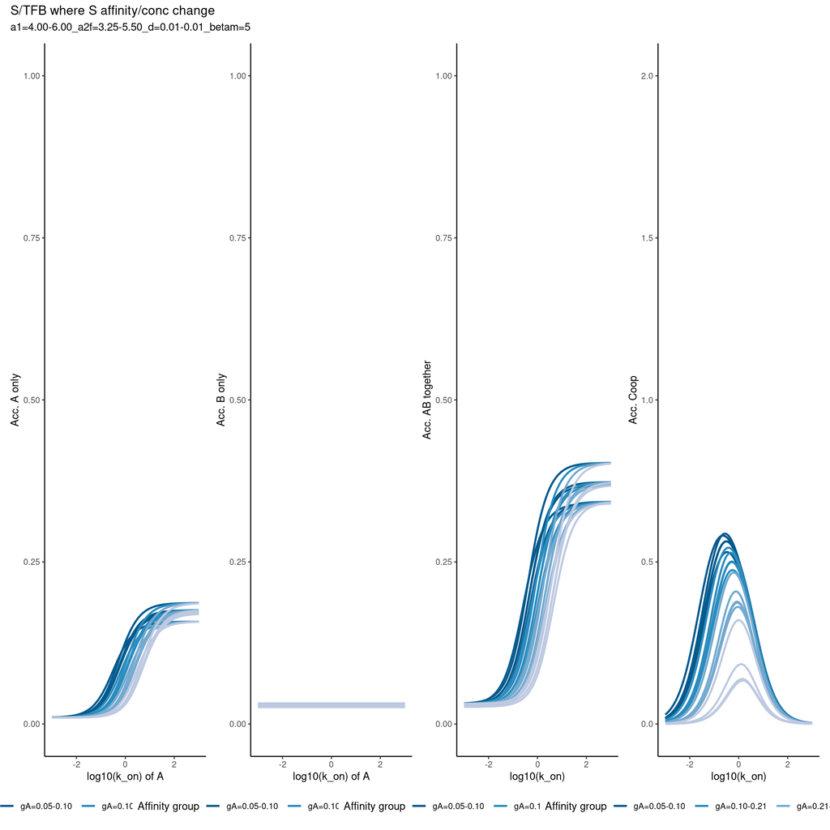

```r
coop.plot<-ggplot(conc.df, aes(x = log10_kon, y = acc_coopvals, color = g_class, group = interaction(trial, g_class)))+
  geom_line(size = 1) +
  scale_x_continuous(name = 'log10(k_on)')+
  scale_y_continuous(name = 'Acc. Coop', limits = c(0, 2))+
  scale_color_manual(values = rev(colors), name = 'Affinity group')+
  theme_classic() + theme(legend.position = 'bottom')


conc.plots<-single.plot + singleB.plot + double.plot + coop.plot + plot_layout(nrow = 1) + plot_annotation(title = 'S/TFB where S affinity/conc change', subtitle = 'a1=4.00-6.00_a2f=3.25-5.50_d=0.01-0.01_betam=5')
conc.plots
```

```r
ggsave(paste0(figure_filepath, '/conc_S_vs_TFB_open_region_mid_pioneering.png'), conc.plots, height = 4, width = 12)
ggsave(paste0(figure_filepath, '/conc_S_vs_TFB_open_region_mid_pioneering.pdf'), conc.plots, height = 4, width = 12)
```

Plot binding occupancy over changing concentrations

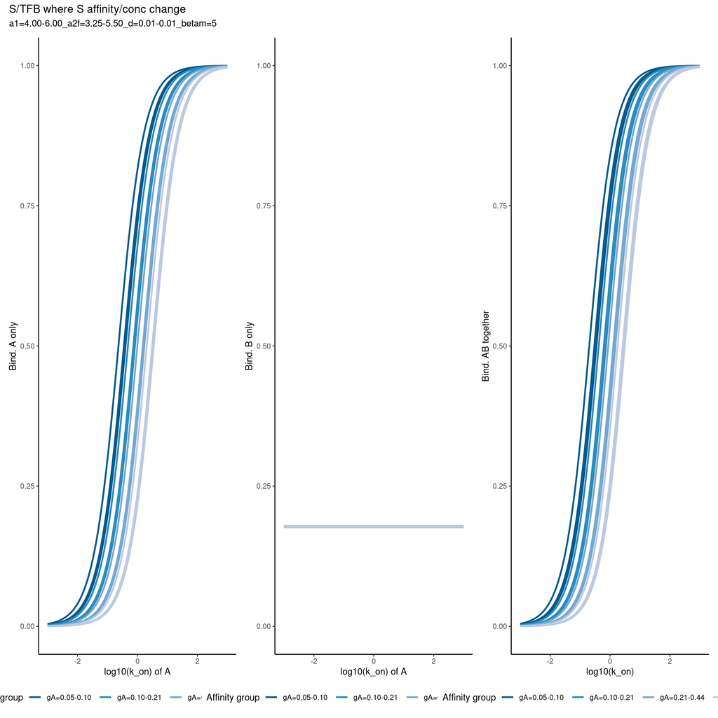

```r
#Visualize features
single.plot<-ggplot(conc.df, aes(x = log10_kon, y = bind_Aonly, color = g_class, group = interaction(trial, g_class)))+
  geom_line(size = 1) +
  scale_x_continuous(name = 'log10(k_on) of A')+
  scale_y_continuous(name = 'Bind. A only', limits = c(0, 1))+
  scale_color_manual(values = rev(colors), name = 'Affinity group')+
  theme_classic() + theme(legend.position = 'bottom')

singleB.plot<-ggplot(conc.df, aes(x = log10_kon, y = bind_Bonly, color = g_class, group = interaction(trial, g_class)))+
  geom_line(size = 1) +
  scale_x_continuous(name = 'log10(k_on) of A')+
  scale_y_continuous(name = 'Bind. B only', limits = c(0, 1))+
  scale_color_manual(values = rev(colors), name = 'Affinity group')+
  theme_classic() + theme(legend.position = 'bottom')


double.plot<-ggplot(conc.df, aes(x = log10_kon, y = bindA_ABonly, color = g_class, group = interaction(trial, g_class)))+
  geom_line(size = 1) +
  scale_x_continuous(name = 'log10(k_on)')+
  scale_y_continuous(name = 'Bind. AB together', limits = c(0, 1))+
  scale_color_manual(values = rev(colors), name = 'Affinity group')+
  theme_classic() + theme(legend.position = 'bottom')


conc.plots<-single.plot + singleB.plot + double.plot + plot_layout(nrow = 1) + plot_annotation(title = 'S/TFB where S affinity/conc change',
                                                                                               subtitle = 'a1=4.00-6.00_a2f=3.25-5.50_d=0.01-0.01_betam=5')
conc.plots
```

```r
ggsave(paste0(figure_filepath, '/conc_S_vs_TFB_open_region_mid_pioneering_binding_occupancy.png'), conc.plots, height = 4, width = 12)
ggsave(paste0(figure_filepath, '/conc_S_vs_TFB_open_region_mid_pioneering_binding_occupancy.pdf'), conc.plots, height = 4, width = 12)
```

Plot the curve derivatives.

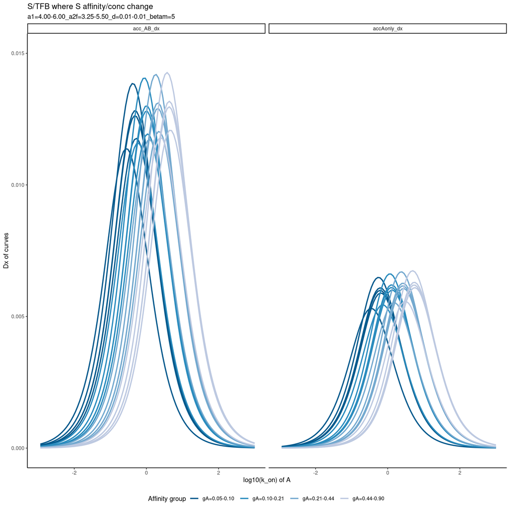

```r
conc_w_dx.df<-conc.df %>%
  dplyr::mutate(accAonly_dx = c(NA, diff(acc_Aonly)),
                acc_AB_dx = c(NA, diff(acc_AB))) %>%
  tidyr::pivot_longer(cols = c(accAonly_dx, acc_AB_dx), names_to = 'measurement', values_to = 'dx') %>%
  as.data.frame

#Visualize features
dx.plot<-ggplot(conc_w_dx.df, aes(x = log10_kon, y = dx, color = g_class, group = interaction(trial, g_class)))+
  geom_line(size = 1) +
  scale_x_continuous(name = 'log10(k_on) of A')+
  scale_y_continuous(name = 'Dx of curves', limits = c(0, 0.015))+
  facet_grid(. ~ measurement)+
  scale_color_manual(values = rev(colors), name = 'Affinity group')+
  ggtitle('S/TFB where S affinity/conc change', subtitle = 'a1=4.00-6.00_a2f=3.25-5.50_d=0.01-0.01_betam=5')+
  theme_classic() + theme(legend.position = 'bottom')
dx.plot
```

```r
ggsave(paste0(figure_filepath, '/conc_S_vs_TFB_open_region_mid_pioneering_curve_derivatives.png'), dx.plot, height = 4, width = 8)
ggsave(paste0(figure_filepath, '/conc_S_vs_TFB_open_region_mid_pioneering_curve_derivatives.pdf'), dx.plot, height = 4, width = 8)
```

#### Hill coefficients

Calculate Hill coefficients for each of these features. Better documentation comes from another package (https://search.r-project.org/CRAN/refmans/braidrm/html/findBestHill.html).

```r
#Calculate median scores across trials
conc_summary.df<-conc.df %>%
  dplyr::group_by(g_class, kon) %>%
  dplyr::summarize(med_acc_Aonly = median(acc_Aonly),
                   med_acc_Bonly = median(acc_Bonly),
                   med_acc_AB = median(acc_AB))

hill_fit_model<-'m3plc'

#Calculate Hill coefficient where max is the plateau ceiling
max_is_ceiling.df<-lapply(conc_summary.df$g_class %>% unique, function(x){
  c.df<-conc_summary.df %>% dplyr::filter(g_class==x)

  fit<-basicdrm::findBestHillModel(formula = c.df$kon, data = c.df$med_acc_Aonly,
                                   defaults = c(0, max(c.df$med_acc_Aonly)))
  A.df<-fit$allfits[[hill_fit_model]]$coefficients %>% t()  %>% as.data.frame() %>%
    dplyr::mutate(gA = x,
                  state = 'A_only')


  fit<-basicdrm::findBestHillModel(formula = c.df$kon, data = c.df$med_acc_Bonly,,
                                   defaults = c(0, max(c.df$med_acc_Bonly)))
  B.df<-fit$allfits[[hill_fit_model]]$coefficients %>% t()  %>% as.data.frame() %>%
    dplyr::mutate(gA = x,
                  state = 'B_only')

  fit<-basicdrm::findBestHillModel(formula = c.df$kon, data = c.df$med_acc_AB,,
                                   defaults = c(0, max(c.df$med_acc_AB)))
  AB.df<-fit$allfits[[hill_fit_model]]$coefficients %>% t()  %>% as.data.frame() %>%
    dplyr::mutate(gA = x,
                  state = 'AB')

  return(rbind(A.df, B.df, AB.df))
}) %>% rbindlist()
print(max_is_ceiling.df)

#Calculate Hill coefficient where p(open)=1 is the plateau ceiling
p100_is_ceiling.df<-lapply(conc_summary.df$g_class %>% unique, function(x){
  c.df<-conc_summary.df %>% dplyr::filter(g_class==x)

  fit<-basicdrm::findBestHillModel(formula = c.df$kon, data = c.df$med_acc_Aonly,
                                   defaults = c(0, 1))
  A.df<-fit$allfits[[hill_fit_model]]$coefficients %>% t()  %>% as.data.frame() %>%
    dplyr::mutate(gA = x,
                  state = 'A_only')


  fit<-basicdrm::findBestHillModel(formula = c.df$kon, data = c.df$med_acc_Bonly,,
                                   defaults = c(0, 1))
  B.df<-fit$allfits[[hill_fit_model]]$coefficients %>% t()  %>% as.data.frame() %>%
    dplyr::mutate(gA = x,
                  state = 'B_only')

  fit<-basicdrm::findBestHillModel(formula = c.df$kon, data = c.df$med_acc_AB,,
                                   defaults = c(0,1))
  AB.df<-fit$allfits[[hill_fit_model]]$coefficients %>% t()  %>% as.data.frame() %>%
    dplyr::mutate(gA = x,
                  state = 'AB')

  return(rbind(A.df, B.df, AB.df))
}) %>% rbindlist()
print(p100_is_ceiling.df)
```

[output not shown]

## S/TFB when both S and TFB can change affinities and concentrations

```r
scenarios.df<-readr::read_tsv('tsv/kinetics/S_vs_TFB_changing_variables.tsv')
scenarios.df$konA %>% summary()
```

```
##      Min.   1st Qu.    Median      Mean   3rd Qu.      Max.
##    0.0010    0.0317    1.0024   76.7748   31.6819 1000.0000
```

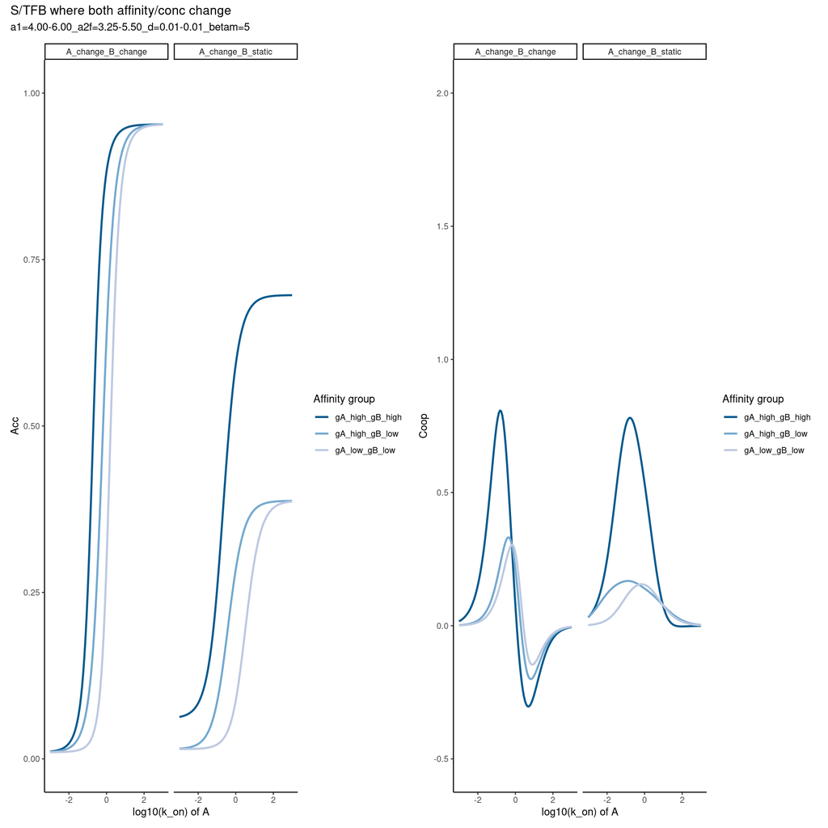

```r
# colors3<-RColorBrewer::brewer.pal(n=3, name="Blues")
colors3<-c('#bdc9e1','#74a9cf','#045a8d')


acc.plot<-scenarios.df %>%
  dplyr::filter((conc_scenario=='A_change_B_static')|(konA==konB)) %>%
  dplyr::filter(affinity_scenario != 'gA_low_gB_high') %>%
  ggplot(., aes(x = log10(konA), y = acc_AB, color = affinity_scenario))+
  geom_line(size = 1) +
  scale_x_continuous(name = 'log10(k_on) of A')+
  scale_y_continuous(name = 'Acc', limits = c(0, 1))+
  scale_color_manual(values = rev(colors3), name = 'Affinity group')+
  facet_grid(. ~ conc_scenario)+
  theme_classic() + theme(legend.position = 'right')

coop.plot<-scenarios.df %>%
  dplyr::filter((conc_scenario=='A_change_B_static')|(konA==konB)) %>%
  dplyr::filter(affinity_scenario != 'gA_low_gB_high') %>%
  ggplot(., aes(x = log10(konA), y = acc_coopvals, color = affinity_scenario))+
  geom_line(size = 1) +
  scale_x_continuous(name = 'log10(k_on) of A')+
  scale_y_continuous(name = 'Coop', limits = c(-.5, 2))+
  scale_color_manual(values = rev(colors3), name = 'Affinity group')+
  facet_grid(. ~ conc_scenario)+
  theme_classic() + theme(legend.position = 'right')


changing_modes<-acc.plot + coop.plot + plot_layout(nrow = 1) + plot_annotation(title = 'S/TFB where both affinity/conc change', subtitle = 'a1=4.00-6.00_a2f=3.25-5.50_d=0.01-0.01_betam=5')
changing_modes
```

```r
ggsave(paste0(figure_filepath, '/conc_S_vs_TFB_open_region_both_change.png'), changing_modes, height = 4, width = 12)
ggsave(paste0(figure_filepath, '/conc_S_vs_TFB_open_region_both_change.pdf'), changing_modes, height = 4, width = 12)
```

# Run parameter controls (Sox2 alone)

## Non-equilibrium

Show that g, o, c, betam, and d have differential effects on concentration curves according to our models.

```r
controls.df<-readr::read_tsv('tsv/kinetics/kinetics_8state_parameter_controls_for_Aonly_sox2.tsv')
control_key.list<-list(affinity = 'gA', opening = 'a1mA', closing = 'a2mA', d = 'kclose0', betam = 'betamA')

controls_formatted.plot<-lapply(controls.df$control %>% unique, function(x){
  print(x)

  #Rows are trials, comma separators are the concentrations
  A_only.df<-controls.df %>% dplyr::filter(control==x) %>% dplyr::mutate(parameter_range = 1:nrow(.)) %>% tidyr::separate(col = 'acc_Aonly', sep = ',', into = c(1:conc_levels_n) %>% as.character) %>%
    tidyr::pivot_longer(cols = c(1:conc_levels_n) %>% as.character, names_to = 'conc_levels', values_to = 'acc_Aonly') %>%
    dplyr::select(acc_Aonly, conc_levels, parameter_range) %>%
    dplyr::mutate(acc_Aonly = as.numeric(acc_Aonly))

  B_only.df<-controls.df %>% dplyr::filter(control==x) %>% dplyr::mutate(parameter_range = 1:nrow(.)) %>% tidyr::separate(col = 'acc_Bonly', sep = ',', into = c(1:conc_levels_n) %>% as.character) %>%
    tidyr::pivot_longer(cols = c(1:conc_levels_n) %>% as.character, names_to = 'conc_levels', values_to = 'acc_Bonly') %>%
    dplyr::select(acc_Bonly, conc_levels, parameter_range) %>%
    dplyr::mutate(acc_Bonly = as.numeric(acc_Bonly))

  #Assign parameters in case people are interested
  parameter_order<-c('kon', 'konB', 'koff1nA','koff1nB','gA','gB','betanA', 'betanB', 'betamA', 'betamB','h0','h1', 'kopen0','kclose0', 'a1nA', 'a1nB', 'a1nAB', 'a1mA', 'a1mB', 'a1mAnB', 'a1nAmB', 'a1mAmB', 'a2nA', 'a2nB', 'a2nAB', 'a2mA', 'a2mB', 'a2mAnB', 'a2nAmB', 'a2mAmB')
  parameters.df<-controls.df %>% dplyr::filter(control==x) %>% dplyr::mutate(parameter_range = 1:nrow(.)) %>% tidyr::separate(col = 'parset', sep = ',', into = parameter_order) %>% dplyr::select(parameter_order, parameter_range) %>% dplyr::select(-kon) %>% as.data.frame()

  df<-A_only.df %>%
    dplyr::left_join(B_only.df) %>%
    dplyr::left_join(parameters.df) %>%
    dplyr::mutate(parameter_of_interest = as.numeric(!!sym(control_key.list[[x]]))) %>%
    dplyr::select(acc_Aonly, acc_Bonly, conc_levels, parameter_range, parameter_of_interest) %>%
    dplyr::mutate(conc_levels = as.integer(conc_levels)) %>%
    dplyr::left_join(conc_levels.df)

  #Custom process values to project them fairly
  if(x=='d'){
    df$parameter_of_interest_final<-0.05/df$parameter_of_interest
    x = 'k_close'
  }
  # else if (x=='closing') {
  #   df$parameter_of_interest_final<-1/df$parameter_of_interest
  #   x = '1/close'
  # }
  else {
    df$parameter_of_interest_final<-df$parameter_of_interest
  }

  # colors<-c('#bdc9e1','#74a9cf','#2b8cbe','#045a8d', '#08306b')
  #Visualize features
  single.plot<-ggplot(df, aes(x = log10_kon, y = acc_Aonly, color = parameter_of_interest_final, group = parameter_of_interest_final))+
    geom_line(aes(y = acc_Bonly, group = parameter_of_interest_final), color = 'red', size = 1) +
    geom_line(size = 1) +
    geom_hline(yintercept = 1, linetype = 'dashed')+
    scale_x_continuous(name = 'log10(k_on) of A')+
    scale_y_continuous(name = 'Acc. A only', limits = c(0, 1))+
    scale_color_gradient(high = '#3f007d', low = '#bcbddc', name = x)+
    # scale_color_manual(values = rev(colors), name = x)+
    # scale_color_manual(values = rev(RColorBrewer::brewer.pal(df$parameter_of_interest %>% unique %>% length, "Blues")), name = x)+
    ggtitle('Sox2 on Sox2 motif', subtitle = x)+
    theme_classic() + theme(legend.position = 'bottom')

  if(x %in% c('k_close', 'affinity')){
    single.plot<-single.plot + scale_color_gradient(high = '#bcbddc', low = '#3f007d', name = x, trans = "log")
  }
  if(x %in% c('closing')){
    single.plot<-single.plot + scale_color_gradient(low = '#bcbddc', high = '#3f007d', name = x, trans = "log")
  }

  return(single.plot)

}) %>% wrap_plots(nrow = 1)
```

```
## [1] "affinity"
```

```
## [1] "opening"
```

```
## [1] "closing"
```

```
## [1] "d"
```

```
## [1] "betam"
```

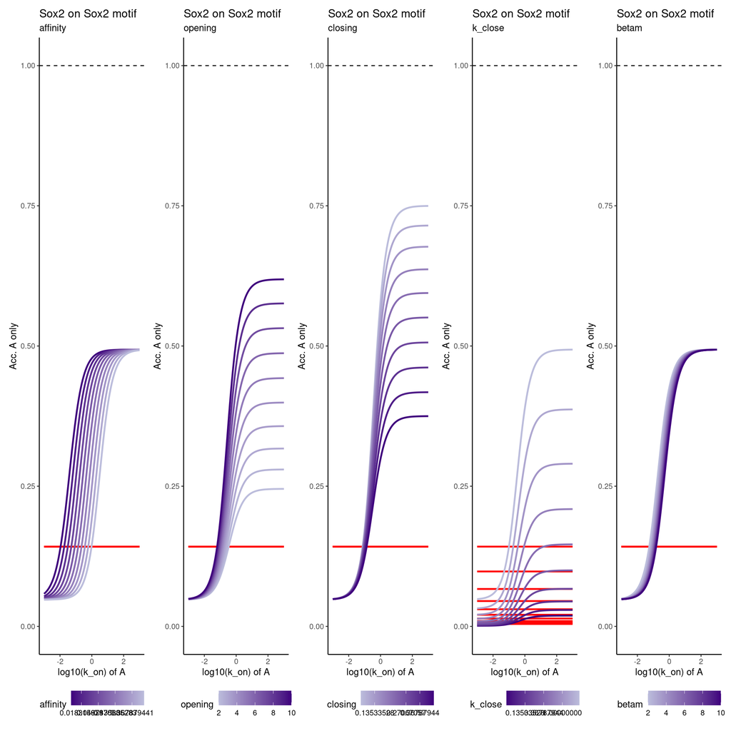

```r
controls_formatted.plot
```

```r
ggsave(paste0(figure_filepath, '/conc_S_parameter_controls.png'), controls_formatted.plot, height = 4, width = 20)
ggsave(paste0(figure_filepath, '/conc_S_parameter_controls.pdf'), controls_formatted.plot, height = 4, width = 20)
```

## Equilibrium

Show that g, betam, and d have differential effects on concentration curves according to our models.

```r
controls.df<-readr::read_tsv('tsv/kinetics/kinetics_4state_parameter_controls_for_equilibrium_sox2.tsv')
control_key.list<-list(affinity = 'gA', d = 'kclose0', betam = 'betamA')

controls_formatted.plot<-lapply(controls.df$control %>% unique, function(x){
  print(x)

  #Rows are trials, comma separators are the concentrations
  A_only.df<-controls.df %>% dplyr::filter(control==x) %>% dplyr::mutate(parameter_range = 1:nrow(.)) %>% tidyr::separate(col = 'acc_A', sep = ',', into = c(1:conc_levels_n) %>% as.character) %>%
    tidyr::pivot_longer(cols = c(1:conc_levels_n) %>% as.character, names_to = 'conc_levels', values_to = 'acc_A') %>%
    dplyr::select(acc_A, conc_levels, parameter_range) %>%
    dplyr::mutate(acc_A = as.numeric(acc_A))

  #Assign parameters in case people are interested
  parameter_order<-c('kon', 'koff1nA','gA','betanA', 'betamA','kopen0','kclose0', 'a1nA', 'a1mA','a2nA', 'a2mA')
  parameters.df<-controls.df %>% dplyr::filter(control==x) %>% dplyr::mutate(parameter_range = 1:nrow(.)) %>% tidyr::separate(col = 'parset', sep = ',', into = parameter_order) %>% dplyr::select(parameter_order, parameter_range) %>% dplyr::select(-kon) %>% as.data.frame()

  df<-A_only.df %>%
    dplyr::left_join(parameters.df) %>%
    dplyr::mutate(parameter_of_interest = as.numeric(!!sym(control_key.list[[x]]))) %>%
    dplyr::select(acc_A, conc_levels, parameter_range, parameter_of_interest) %>%
    dplyr::mutate(conc_levels = as.integer(conc_levels)) %>%
    dplyr::left_join(conc_levels.df)


    #Custom process values to project them fairly
  if(x=='d'){
    df$parameter_of_interest_final<-0.05/df$parameter_of_interest
    x = 'k_close'
  } else {
    df$parameter_of_interest_final<-df$parameter_of_interest
  }

  #Visualize features
  single.plot<-ggplot(df, aes(x = log10_kon, y = acc_A, color = parameter_of_interest_final, group = parameter_of_interest_final))+
    geom_line(size = 1) +
    geom_hline(yintercept = 1, linetype = 'dashed')+
    scale_x_continuous(name = 'log10(k_on) of A')+
    scale_y_continuous(name = 'Acc. A only', limits = c(0, 1))+
    scale_color_gradient(high = '#3f007d', low = '#bcbddc', name = x)+
    # scale_color_manual(values = rev(colors), name = x)+
    # scale_color_manual(values = rev(RColorBrewer::brewer.pal(df$parameter_of_interest %>% unique %>% length, "Blues")), name = x)+
    ggtitle('Sox2 on Sox2 motif', subtitle = x)+
    theme_classic() + theme(legend.position = 'bottom')

  if(x %in% c('k_close', 'affinity')){
    single.plot<-single.plot + scale_color_gradient(high = '#bcbddc', low = '#3f007d', name = x, trans = "log")
  }
  if(x %in% c('closing')){
    single.plot<-single.plot + scale_color_gradient(low = '#bcbddc', high = '#3f007d', name = x, trans = "log")
  }
  return(single.plot)

}) %>% wrap_plots(nrow = 1)
```

```
## [1] "affinity"
```

```
## [1] "d"
```

```
## [1] "betam"
```

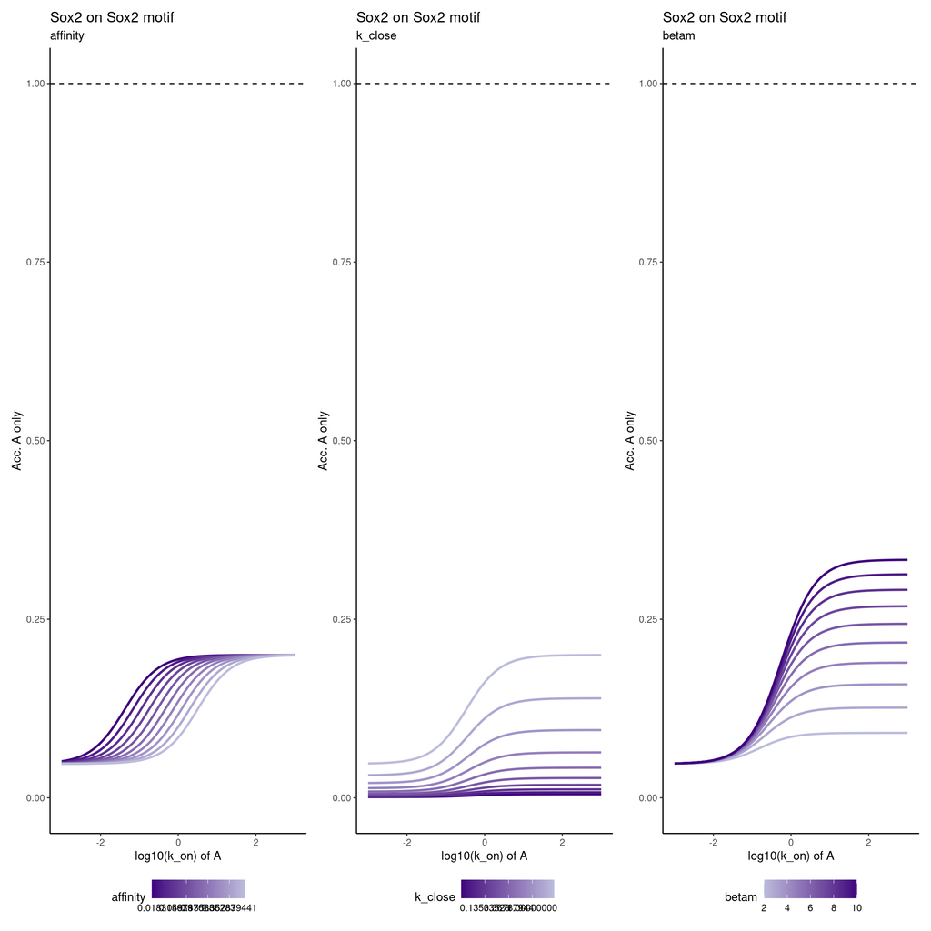

```r
controls_formatted.plot
```

```r
ggsave(paste0(figure_filepath, '/conc_S_parameter_controls_equilibrium.png'), controls_formatted.plot, height = 4, width = 20)
ggsave(paste0(figure_filepath, '/conc_S_parameter_controls_equilibrium.pdf'), controls_formatted.plot, height = 4, width = 20)
```